# Machine Learning for Prediction of Personal Activities

*Author: Huili Wang*

## Overview

Devices such as Jawbone Up, Nike FuelBand, and Fitbit are equipped with accelerometers. Using these devices, it is now possible to collect a large amount of data about personal activity relatively inexpensively. This report uses a dataset collected from the accelerometers to determine whether personal activities are performed correctly. The goal is to investigate the best machine learning algorithm to predict how well the pseronal activities are performed.

This investigation started with data cleansing to remove NA values from the training dataset and then performed prelimanary feature selection to remove near-zero values, which led in a reduction of the number of features from 159 to 53 as a result.

The feature reduction was followed by an exploratory analysis focusing on two aspects of data: skewness and feature interdependency. An outlier observation was identified and removed from the dataset as a result. Also, the analysis indicates high dependecies among features.

Based on the result of the exploratory analysis, a prectitive model is built which strikes the balance of accuracy, kappa (a measure of concordance) and computational performance in an computational environment with limited computational resources. The prective model uses the random forest method with the tuning parameter *mtry* set to 8. The number of features used to build the model is 53. The model accuracy and kappa are 0.999 and 0.998, respectively.

## Data Cleansing

The data used in this report are collected from accelerometers on the belt, forearm, arm, and dumbell of 6 participants. They were asked to perform barbell lifts correctly and incorrectly in 5 different ways. More information is available from the website here: http://groupware.les.inf.puc-rio.br/har (see the section on the Weight Lifting Exercise Dataset).

It is noticed that some features in the dataset contain more than 97% of NA values in all observations. The features containing such high percentage of NA values are not useful for machine learning and hence removed from the data frame using the following R statements. With the removal, the updated dataset contains no NA values and no data imputation is required as a result.

```r
dat = read.csv("https://d396qusza40orc.cloudfront.net/predmachlearn/pml-training.csv")
namat <- is.na(dat)
navec <- apply(namat,2,sum)
navec <- navec / nrow(dat)
nacol <- navec > 0.97
nnacol <- subset(nacol, nacol == FALSE)
nnadat <- dat[,names(nnacol)]
```

## Preliminary Feature Selection

It is also noticed that the some features have near-zero variations which are not useful for matching learning either. These features are removed by the following R statements.

```r
library(caret)
nzv <- nearZeroVar(nnadat,saveMetrics = TRUE)
nnzvcol <- subset(nzv, nzv == FALSE)
datTidy <- nnadat[,row.names(nnzvcol)]
```

The *classe* feature has possible values of A, B, C, D, and E as defined in this [web page](http://groupware.les.inf.puc-rio.br/har#weight_lifting_exercises). These possible values represent different ways of weight lifting which have nothing to do with names of the weigh lifters, timestamps and sequence of observations. Therefore, the following five features are excluded for machine learning: *X*, *user_name*, *raw_timestamp_part_1*, *raw_timestamp_part_2*, and *cvtd_timestamp*. Excluding these five features, the tidy dataset is further reduced by the following R statements.

```r
datTidy <- datTidy[,!(colnames(datTidy) %in% c('X','user_name','raw_timestamp_part_1','raw_timestamp_part_2','cvtd_timestamp'))]
```

The remaining 53 features used for machine learning which are reduced from the original total of 159 ones are

```r
names(datTidy[,colnames(datTidy) != 'classe'])
```

```
##  [1] "num_window"           "roll_belt"            "pitch_belt"
##  [4] "yaw_belt"             "total_accel_belt"     "gyros_belt_x"
##  [7] "gyros_belt_y"         "gyros_belt_z"         "accel_belt_x"
## [10] "accel_belt_y"         "accel_belt_z"         "magnet_belt_x"
## [13] "magnet_belt_y"        "magnet_belt_z"        "roll_arm"
## [16] "pitch_arm"            "yaw_arm"              "total_accel_arm"
## [19] "gyros_arm_x"          "gyros_arm_y"          "gyros_arm_z"
## [22] "accel_arm_x"          "accel_arm_y"          "accel_arm_z"
## [25] "magnet_arm_x"         "magnet_arm_y"         "magnet_arm_z"
## [28] "roll_dumbbell"        "pitch_dumbbell"       "yaw_dumbbell"
## [31] "total_accel_dumbbell" "gyros_dumbbell_x"     "gyros_dumbbell_y"
## [34] "gyros_dumbbell_z"     "accel_dumbbell_x"     "accel_dumbbell_y"
## [37] "accel_dumbbell_z"     "magnet_dumbbell_x"    "magnet_dumbbell_y"
## [40] "magnet_dumbbell_z"    "roll_forearm"         "pitch_forearm"
## [43] "yaw_forearm"          "total_accel_forearm"  "gyros_forearm_x"
## [46] "gyros_forearm_y"      "gyros_forearm_z"      "accel_forearm_x"
## [49] "accel_forearm_y"      "accel_forearm_z"      "magnet_forearm_x"
## [52] "magnet_forearm_y"     "magnet_forearm_z"
```

## Exploratory Analysis

The data for each features is further examined on its skewness. The features with high sknewness are singled out by the following R statements

```r
library(e1071)
```

```r
datSkewness <- apply(datTidy[,names(datTidy) != 'classe'],2,skewness)
datSkewness[datSkewness > 3]
```

```
## gyros_dumbbell_y gyros_dumbbell_z  gyros_forearm_y  gyros_forearm_z
##         31.64827        135.95344         51.32379        116.07619
```

Normal Q-Q plots of these features as follows indicate that the sknewness is due to an outliner observation.

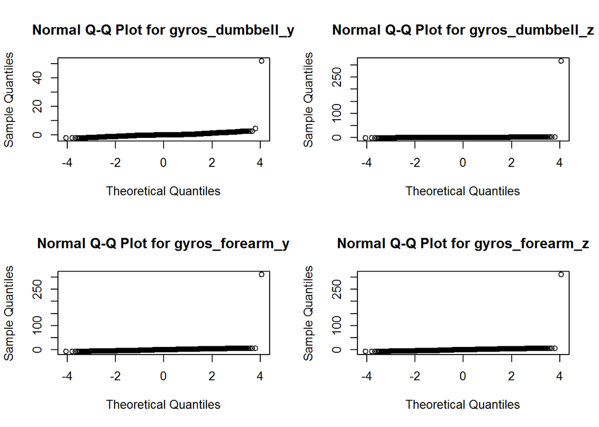

```r
par(mfrow=c(2,2))
qqnorm(datTidy$gyros_dumbbell_y,main="Normal Q-Q Plot for gyros_dumbbell_y")
qqnorm(datTidy$gyros_dumbbell_z,main="Normal Q-Q Plot for gyros_dumbbell_z")
qqnorm(datTidy$gyros_forearm_y,main="Normal Q-Q Plot for gyros_forearm_y")
qqnorm(datTidy$gyros_forearm_y,main="Normal Q-Q Plot for gyros_forearm_z")
```

The outlier observation is identified by using the *summary* and *which* R commands as follows:

```r
summ <- summary(datTidy$gyros_dumbbell_y)
summ
```

```
##     Min.  1st Qu.   Median     Mean  3rd Qu.     Max.
## -2.10000 -0.14000  0.03000  0.04606  0.21000 52.00000
```

```r
outlierRowIndex <- which(datTidy$gyros_dumbbell_y == summ[6],arr.ind = TRUE)
outlierRowIndex
```

```
## [1] 5373
```

```r
summ <- summary(datTidy$gyros_dumbbell_z)
summ
```

```
##    Min. 1st Qu.  Median    Mean 3rd Qu.    Max.
##  -2.380  -0.310  -0.130  -0.129   0.030 317.000
```

```r
outlierRowIndex <- which(datTidy$gyros_dumbbell_z == summ[6],arr.ind = TRUE)
outlierRowIndex
```

```
## [1] 5373
```

```r
summ <- summary(datTidy$gyros_forearm_y)
summ
```

```
##      Min.   1st Qu.    Median      Mean   3rd Qu.      Max.
##  -7.02000  -1.46000   0.03000   0.07517   1.62000 311.00000
```

```r
outlierRowIndex <- which(datTidy$gyros_forearm_y == summ[6],arr.ind = TRUE)
outlierRowIndex
```

```
## [1] 5373
```

```r
summ <- summary(datTidy$gyros_forearm_z)
summ
```

```
##     Min.  1st Qu.   Median     Mean  3rd Qu.     Max.
##  -8.0900  -0.1800   0.0800   0.1512   0.4900 231.0000
```

```r
outlierRowIndex <- which(datTidy$gyros_forearm_z == summ[6],arr.ind = TRUE)
outlierRowIndex
```

```
## [1] 5373
```

After removing the outliner observation, the normal Q-Q plots become

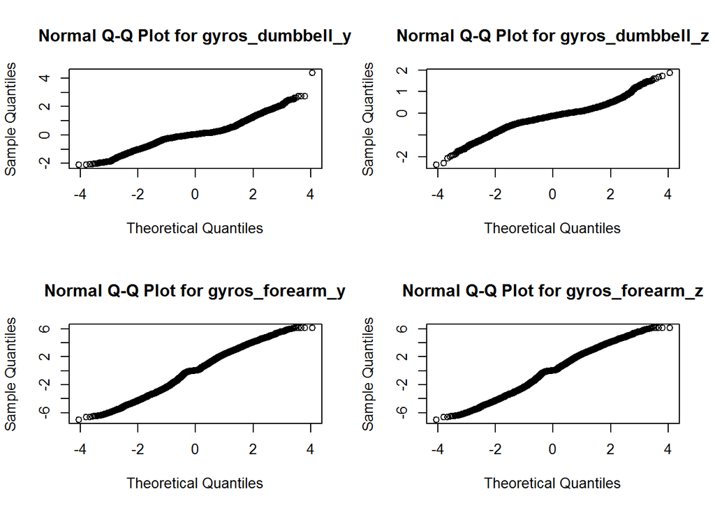

```r
datTidy <- datTidy[-outlierRowIndex,]
par(mfrow=c(2,2))
qqnorm(datTidy$gyros_dumbbell_y,main="Normal Q-Q Plot for gyros_dumbbell_y")
qqnorm(datTidy$gyros_dumbbell_z,main="Normal Q-Q Plot for gyros_dumbbell_z")
qqnorm(datTidy$gyros_forearm_y,main="Normal Q-Q Plot for gyros_forearm_y")
qqnorm(datTidy$gyros_forearm_y,main="Normal Q-Q Plot for gyros_forearm_z")
```

In addition to the skewness study of the features, correlations among them are also examined. The correlations are computed by using the following R statements.

```r
featMat <- datTidy[,colnames(datTidy) != 'classe']
featCorMat <- cor(featMat)
hicor_p9 <- which(featCorMat < 1 & featCorMat > 0.9, arr.ind = TRUE)
hicor_p8 <- which(featCorMat < 1 & featCorMat > 0.8, arr.ind = TRUE)
hicor_p7 <- which(featCorMat < 1 & featCorMat > 0.7, arr.ind = TRUE)
hicor_p6 <- which(featCorMat < 1 & featCorMat > 0.6, arr.ind = TRUE)
```

The correlation analysis indicates that the numbers of highly correlated pairs of features with their correlation coefficients equal to 0.9, 0.8, 0.7 and 0.6 are 3, 9, 20 and 25 out of the total number of features 53, respectively. In other words, a large portion of features are highly correlated.

The highly correlated features transpires that there might be a subset of features explaining most variations of the observations. The principal component analysis is employed to examine the transpiration. The result of the analysis is summarized in the following plot.

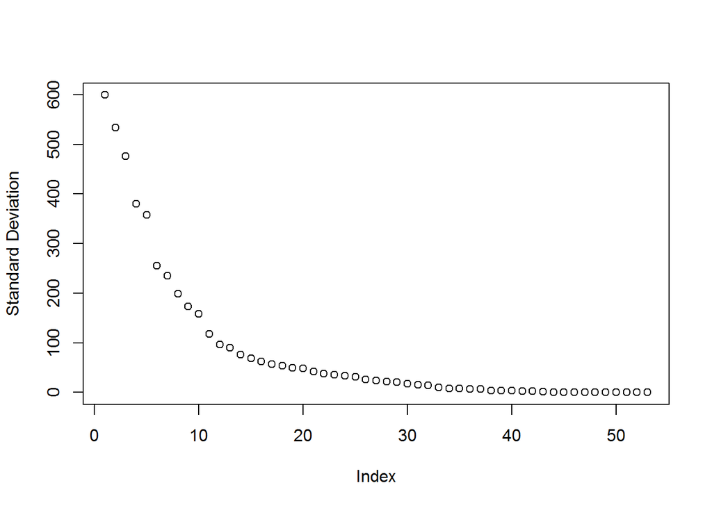

```r
prComp <- prcomp(featMat)
plot(prComp$sdev, ylab="Standard Deviation")
```

The plot of *standard deviation* versus *component index* confirms that the number of principal components explaining all variations is much less that the number of features.

## Predictive Modeling

The exploratory analysis performed in the previous section only touched few aspects of the data. Without fully understanding the characteristics of the data, it is advantageous to employ the non-parametric approach to build a predictive model.

The Random Forest method is chosen among others and the result of the modeling is given in the following

```r
set.seed(340091)
rfFit <- train(classe~.,method="rf",data=datTidy,trControl=trainControl(p=0.5,method="cv",savePredictions = TRUE),tuneGrid=data.frame(mtry=8))
rfFit
```

```
## Random Forest
##
## 19621 samples
##    53 predictor
##     5 classes: 'A', 'B', 'C', 'D', 'E'
##
## No pre-processing
## Resampling: Cross-Validated (10 fold)
## Summary of sample sizes: 17659, 17658, 17659, 17658, 17661, 17659, ...
## Resampling results
##
##   Accuracy  Kappa      Accuracy SD  Kappa SD
##   0.998522  0.9981305  0.000738517  0.0009341847
##
## Tuning parameter 'mtry' was held constant at a value of 8
##
```

```r
confusionMatrix(rfFit$pred$pred,rfFit$pred$obs)
```

```
## Confusion Matrix and Statistics
##
##           Reference
## Prediction    A    B    C    D    E
##          A 5579    4    0    0    0
##          B    0 3791    5    0    0
##          C    0    2 3417   13    0
##          D    0    0    0 3202    4
##          E    0    0    0    1 3603
##
## Overall Statistics
##
##                Accuracy : 0.9985
##                  95% CI : (0.9979, 0.999)
##     No Information Rate : 0.2843
##     P-Value [Acc > NIR] : < 2.2e-16
##
##                   Kappa : 0.9981
##  Mcnemar's Test P-Value : NA
##
## Statistics by Class:
##
##                      Class: A Class: B Class: C Class: D Class: E
## Sensitivity            1.0000   0.9984   0.9985   0.9956   0.9989
## Specificity            0.9997   0.9997   0.9991   0.9998   0.9999
## Pos Pred Value         0.9993   0.9987   0.9956   0.9988   0.9997
## Neg Pred Value         1.0000   0.9996   0.9997   0.9991   0.9998
## Prevalence             0.2843   0.1935   0.1744   0.1639   0.1838
## Detection Rate         0.2843   0.1932   0.1742   0.1632   0.1836
## Detection Prevalence   0.2845   0.1935   0.1749   0.1634   0.1837
## Balanced Accuracy      0.9999   0.9991   0.9988   0.9977   0.9994
```

The computation time to build the model is about 12 minutes on a Dell Inspiron 15 laptop computer with Intel CORE i5 running Windows 10.

## Prediction for Project Submission

Project submission requires predictions to be generated from a prescribed set of test data by the predictive model developed in this report. The predictions are computed by using the following R statements

```r
tdat = read.csv("https://d396qusza40orc.cloudfront.net/predmachlearn/pml-testing.csv")
namat <- is.na(tdat)
navec <- apply(namat,2,sum)
navec <- navec / nrow(tdat)
nacol <- navec > 0.97
nnacol <- subset(nacol, nacol == FALSE)
nnatdat <- tdat[,names(nnacol)]
nzv <- nearZeroVar(nnatdat,saveMetrics = TRUE)
nnzvcol <- subset(nzv, nzv == FALSE)
tdatTidy <- nnatdat[,row.names(nnzvcol)]
tdatTidy <- tdatTidy[,!(colnames(tdatTidy) %in% c('X','user_name','raw_timestamp_part_1','raw_timestamp_part_2','cvtd_timestamp'))]
tpred <- predict(rfFit,newdata=tdatTidy)
```

The predictive values are

```r
tpred
```

```
##  [1] B A B A A E D B A A B C B A E E A B B B
## Levels: A B C D E
```

## Conclusion

The analysis performed in this report suggests the random forest method as the machine learning model for predicting personal activities in the computational environment with limited resources is accurate and consistent. The model uses the following features to predict the *classe* outcome variable.

```r
names(datTidy[,colnames(datTidy) != 'classe'])
```

```
##  [1] "num_window"           "roll_belt"            "pitch_belt"
##  [4] "yaw_belt"             "total_accel_belt"     "gyros_belt_x"
##  [7] "gyros_belt_y"         "gyros_belt_z"         "accel_belt_x"
## [10] "accel_belt_y"         "accel_belt_z"         "magnet_belt_x"
## [13] "magnet_belt_y"        "magnet_belt_z"        "roll_arm"
## [16] "pitch_arm"            "yaw_arm"              "total_accel_arm"
## [19] "gyros_arm_x"          "gyros_arm_y"          "gyros_arm_z"
## [22] "accel_arm_x"          "accel_arm_y"          "accel_arm_z"
## [25] "magnet_arm_x"         "magnet_arm_y"         "magnet_arm_z"
## [28] "roll_dumbbell"        "pitch_dumbbell"       "yaw_dumbbell"
## [31] "total_accel_dumbbell" "gyros_dumbbell_x"     "gyros_dumbbell_y"
## [34] "gyros_dumbbell_z"     "accel_dumbbell_x"     "accel_dumbbell_y"
## [37] "accel_dumbbell_z"     "magnet_dumbbell_x"    "magnet_dumbbell_y"
## [40] "magnet_dumbbell_z"    "roll_forearm"         "pitch_forearm"
## [43] "yaw_forearm"          "total_accel_forearm"  "gyros_forearm_x"
## [46] "gyros_forearm_y"      "gyros_forearm_z"      "accel_forearm_x"
## [49] "accel_forearm_y"      "accel_forearm_z"      "magnet_forearm_x"
## [52] "magnet_forearm_y"     "magnet_forearm_z"
```

The predictive model has 0.999 accuracy and 0.998 kappa concordance measurement. The cross-validation accuracy is 0.999. In other words, the cross-validation error rate is 0.001, which is also a good estimate of the out-of-sample error rate.